# Motif manipulation with the “universalmotif” package

Benjamin Tremblay

University of Waterloo, Waterloo, Canada

b2tremblay@uwaterloo.ca

18 août 2018

#### Abstract

Introducing sequence motif types.

# 1 The universalmotif class and conversion utilities

## 1.1 The universalmotif class

The *universalmotif* package stores motifs using the `universalmotif` class. The most basic `universalmotif` object exposes the ‘name’, ‘alphabet’, ‘type’, ‘type’, ‘strand’, ‘icscore’, ‘consensus’, and ‘motif’ slots; furthermore, the ‘pseudocount’ and ‘bkg’ slots are also stored but not shown. `universalmotif` class motifs can be PCM, PPM, PWM, or ICM type.

```r
library(universalmotif)
data(examplemotif)
examplemotif
```

```
#>
#>        Motif name:   motif
#>          Alphabet:   DNA
#>              Type:   PPM
#>           Strands:   +-
#>          Total IC:   14
#>         Consensus:   TATAWAW
#>
#>   T A T A   W A   W
#> A 0 1 0 1 0.5 1 0.5
#> C 0 0 0 0 0.0 0 0.0
#> G 0 0 0 0 0.0 0 0.0
#> T 1 0 1 0 0.5 0 0.5
```

Exposing the motif class with `str` shows the other available slots:

```
#> Formal class 'universalmotif' [package "universalmotif"] with 19 slots
#>   ..@ name       : chr "motif"
#>   ..@ altname    : chr(0)
#>   ..@ family     : chr(0)
#>   ..@ organism   : chr(0)
#>   ..@ motif      : num [1:4, 1:7] 0 0 0 1 1 0 0 0 0 0 ...
#>   .. ..- attr(*, "dimnames")=List of 2
#>   .. .. ..$ : chr [1:4] "A" "C" "G" "T"
#>   .. .. ..$ : chr [1:7] "T" "A" "T" "A" ...
#>   ..@ alphabet   : chr "DNA"
#>   ..@ type       : chr "PPM"
#>   ..@ icscore    : num 14
#>   ..@ nsites     : num(0)
#>   ..@ pseudocount: num 0
#>   ..@ bkg        : num [1:4] 0.25 0.25 0.25 0.25
#>   ..@ bkgsites   : num(0)
#>   ..@ consensus  : chr "TATAWAW"
#>   ..@ strand     : chr "+-"
#>   ..@ pval       : num(0)
#>   ..@ qval       : num(0)
#>   ..@ eval       : num(0)
#>   ..@ multifreq  : list()
#>   ..@ extrainfo  : chr(0)
```

The other slots will be shown once filled:

```r
library(universalmotif)
data(examplemotif)

## The various slots can be accessed individually using `[`
examplemotif["consensus"]
```

```
#> consensus
#> "TATAWAW"
```

```r
## To change a slot, use `[<-`
examplemotif["family"] <- "My motif family"
examplemotif
```

```
#>
#>        Motif name:   motif
#>            Family:   My motif family
#>          Alphabet:   DNA
#>              Type:   PPM
#>           Strands:   +-
#>          Total IC:   14
#>         Consensus:   TATAWAW
#>
#>   T A T A   W A   W
#> A 0 1 0 1 0.5 1 0.5
#> C 0 0 0 0 0.0 0 0.0
#> G 0 0 0 0 0.0 0 0.0
#> T 1 0 1 0 0.5 0 0.5
```

Though the slots can easily be changed manually with `[<-`, a number of safeguards have been put in place for some of the slots which will prevent incorrect values from being introduced.

```r
library(universalmotif)
data(examplemotif)

## The consensus slot is dependent on the motif matrix
examplemotif["consensus"]
```

```
#> consensus
#> "TATAWAW"
```

```r
## Changing this would mean it no longer matches the motif
examplemotif["consensus"] <- "GGGAGAG"
```

```
#> Error in .local(x, i, ..., value): consensus string for DNA motifs is generated automatically
```

```r
## Another example:
examplemotif["strand"] <- "x"
```

```
#> Error in validObject(x): invalid class "universalmotif" object: motif 'strand' must be either '+', '-', or '+-'
```

```r
## Of course, this can be circumvented by simply using `@`; do this at your
## own risk. Trying to use a motif with an incorrectly filled slot will likely
## cause other universalmotif functions to fail.
examplemotif@strand <- "x"
examplemotif
```

```
#>
#>        Motif name:   motif
#>          Alphabet:   DNA
#>              Type:   PPM
#>           Strands:   x
#>          Total IC:   14
#>         Consensus:   TATAWAW
#>
#>   T A T A   W A   W
#> A 0 1 0 1 0.5 1 0.5
#> C 0 0 0 0 0.0 0 0.0
#> G 0 0 0 0 0.0 0 0.0
#> T 1 0 1 0 0.5 0 0.5
```

Below the exposed metadata slots, the actual ‘motif’ matrix is shown. Each position is its’ own column; row names showing the alphabet letters, and the column names showing the consensus letter at each position.

## 1.2 Converting to and from another package’s class

The *universalmotif* package aims to unify most of the motif-related Bioconductor packages by providing the `convert_motif` function. This allows for easy transition between supported packages (see `?convert_motif` for a complete list of supported packages).

```r
library(universalmotif)
data(examplemotif)
suppressPackageStartupMessages(library(TFBSTools))
data(MA0003.2)
suppressPackageStartupMessages(library(MotifDb))

## convert from a universalmotif to another
convert_motifs(examplemotif, "TFBSTools-PWMatrix")
```

```
#> An object of class PWMatrix
#> ID:
#> Name: motif
#> Matrix Class: Unknown
#> strand: *
#> Pseudocounts: 0.8
#> Tags:
#> list()
#> Background:
#>    A    C    G    T
#> 0.25 0.25 0.25 0.25
#> Matrix:
#>        T      A      T      A       W      A       W
#> A -6.977  1.991 -6.977  1.991  0.9943  1.991  0.9943
#> C -6.977 -6.977 -6.977 -6.977 -6.9773 -6.977 -6.9773
#> G -6.977 -6.977 -6.977 -6.977 -6.9773 -6.977 -6.9773
#> T  1.991 -6.977  1.991 -6.977  0.9943 -6.977  0.9943
```

```r
## convert to universalmotif
convert_motifs(MA0003.2)
```

```
#>
#>        Motif name:   TFAP2A
#>    Alternate name:   MA0003.2
#>            Family:   Helix-Loop-Helix
#>          Organism:   9606
#>          Alphabet:   DNA
#>              Type:   PCM
#>           Strands:   +
#>          Total IC:   12.9
#>         Consensus:   NNNNGCCYSAGGGCA
#>      Target sites:   5098
#>        Extra info:   centrality_logp: -4343
#>                      family: Helix-Loop-Helix
#>                      medline: 10497269
#>                      pazar_tf_id: TF0000002
#>                      source: ENCODE
#>                      tax_group: vertebrates
#>                      tfbs_shape_id: 264
#>                      type: ChIP-seq
#>                      collection: CORE
#>                      species: 9606
#>                      acc: P05549
#>
#>      N    N    N    N    G    C    C    Y    S    A    G    G    G    C    A
#> A 1387 2141  727 1517   56    0    0   62  346 3738  460    0  116  451 3146
#> C 1630 1060 1506  519 1199 5098 4762 1736 2729  236    0    0 1443 3672  690
#> G  851  792  884  985 3712    0    0   85 1715  920 4638 5098 3455  465  168
#> T 1230 1105 1981 2077  131    0  336 3215  308  204    0    0   84  510 1094
```

```r
## convert between two packages
convert_motifs(MotifDb[1], "TFBSTools-ICMatrix")
```

```
#> [[1]]
#> An object of class ICMatrix
#> ID: M0001_1.02
#> Name: ABF1
#> Matrix Class: Unknown
#> strand: *
#> Pseudocounts: 0.8
#> Schneider correction: FALSE
#> Tags:
#> list()
#> Background:
#>    A    C    G    T
#> 0.25 0.25 0.25 0.25
#> Matrix:
#>         T       T       A       T       C       A       C       T
#> A 0.02049 0.02049 1.65964 0.02049 0.02049 1.65964 0.02049 0.02049
#> C 0.02049 0.02049 0.02049 0.02049 1.65964 0.02049 1.65964 0.02049
#> G 0.02049 0.02049 0.02049 0.02049 0.02049 0.02049 0.02049 0.02049
#> T 1.65964 1.65964 0.02049 1.65964 0.02049 0.02049 0.02049 1.65964
```

The `convert_motifs` function is embedded in most of the *universalmotif* functions, meaning that compatible motif classes from other packages can be used without needed to convert them first.

# 2 Importing and exporting motifs

## 2.1 Importing

The *universalmotif* package offers a number of `read_` functions to allow for easy import of various motif formats. These include:

- `read_cisbp`: CIS-BP (Weirauch et al. 2014)
- `read_homer`: HOMER (Heinz et al. 2010)
- `read_jaspar`: JASPAR (Khan et al. 2018)
- `read_meme`: MEME (Bailey et al. 2009)
- `read_transfac`: TRANSFAC (Wingender et al. 1996)
- `read_uniprobe`: UniPROBE (Hume et al. 2015)

These functions should work natively with these formats, but if you are generating your own motifs in one of these formats than it must adhere quite strictly to the format. An example of each of these is included in this package; see `system.file("extdata", package="universalmotif")`.

Additionally, the generic `read_matrix` function can read simply-formatted motif files; each motif can have a header and a motif matrix.

## 2.2 Exporting

Compatible motif classes can be written to disk using:

- `write_homer`
- `write_jaspar`
- `write_matrix`
- `write_meme`
- `write_transfac`

The `write_matrix` function, similar to its’ `read_matrix` counterpart, can write motifs as simple matrices with an optional header.

# 3 Modifying motifs and related functions

## 3.1 Converting motif type

Any `universalmotif` object can transition between PCM, PPM, PWM, and ICM types seamlessly using the `convert_type` function. The only exception to this is if the ICM calculation is performed with sample correction, or as relative entropy. If this occurs, then back conversion to another type will be inaccurate.

```r
library(universalmotif)
data(examplemotif)

## This motif is currently a PPM:
examplemotif["type"]
```

```
#>  type
#> "PPM"
```

```r
## When converting to PCM, the 'nsites' slot is needed to tell it how
## many sequences it originated from. If empty, 100 is used.
convert_type(examplemotif, "PCM")
```

```
#>
#>        Motif name:   motif
#>          Alphabet:   DNA
#>              Type:   PCM
#>           Strands:   +-
#>          Total IC:   14
#>         Consensus:   TATAWAW
#>
#>     T   A   T   A  W   A  W
#> A   0 100   0 100 50 100 50
#> C   0   0   0   0  0   0  0
#> G   0   0   0   0  0   0  0
#> T 100   0 100   0 50   0 50
```

```r
## For converting to PWM, the 'pseudocount' slot is used to determine if any
## correction should be applied:
examplemotif["pseudocount"]
```

```
#> pseudocount
#>           0
```

```r
convert_type(examplemotif, "PWM")
```

```
#>
#>        Motif name:   motif
#>          Alphabet:   DNA
#>              Type:   PWM
#>           Strands:   +-
#>          Total IC:   14
#>         Consensus:   TATAWAW
#>
#>      T    A    T    A    W    A    W
#> A -Inf    2 -Inf    2    1    2    1
#> C -Inf -Inf -Inf -Inf -Inf -Inf -Inf
#> G -Inf -Inf -Inf -Inf -Inf -Inf -Inf
#> T    2 -Inf    2 -Inf    1 -Inf    1
```

```r
## You can either change the 'pseudocount' slot manually beforehand, or pass
## one to 'convert_type'
convert_type(examplemotif, "PWM", pseudocount = 1)
```

```
#>
#>        Motif name:   motif
#>          Alphabet:   DNA
#>              Type:   PWM
#>           Strands:   +-
#>          Total IC:   14
#>         Consensus:   TATAWAW
#>
#>       T     A     T     A      W     A      W
#> A -6.66  1.99 -6.66  1.99  0.993  1.99  0.993
#> C -6.66 -6.66 -6.66 -6.66 -6.658 -6.66 -6.658
#> G -6.66 -6.66 -6.66 -6.66 -6.658 -6.66 -6.658
#> T  1.99 -6.66  1.99 -6.66  0.993 -6.66  0.993
```

```r
## There are a couple of additional options for ICM conversion:
## 'nsize_correction' and 'relative_entropy'. The former uses the
## TFBSTools:::schneider_correction function for sample size correction.
## The latter uses the 'bkg' slot to calculate information content.
examplemotif["nsites"] = 10
convert_type(examplemotif, "ICM", nsize_correction = FALSE)
```

```
#>
#>        Motif name:   motif
#>          Alphabet:   DNA
#>              Type:   ICM
#>           Strands:   +-
#>          Total IC:   14
#>         Consensus:   TATAWAW
#>      Target sites:   10
#>
#>   T A T A   W A   W
#> A 0 2 0 2 0.5 2 0.5
#> C 0 0 0 0 0.0 0 0.0
#> G 0 0 0 0 0.0 0 0.0
#> T 2 0 2 0 0.5 0 0.5
```

```r
convert_type(examplemotif, "ICM", nsize_correction = TRUE)
```

```
#>
#>        Motif name:   motif
#>          Alphabet:   DNA
#>              Type:   ICM
#>           Strands:   +-
#>          Total IC:   14
#>         Consensus:   TATAWAW
#>      Target sites:   10
#>
#>      T    A    T    A     W    A     W
#> A 0.00 1.75 0.00 1.75 0.377 1.75 0.377
#> C 0.00 0.00 0.00 0.00 0.000 0.00 0.000
#> G 0.00 0.00 0.00 0.00 0.000 0.00 0.000
#> T 1.75 0.00 1.75 0.00 0.377 0.00 0.377
```

```r
examplemotif["bkg"] = c(0.4, 0.1, 0.1, 0.4)
convert_type(examplemotif, "ICM", relative_entropy = TRUE)
```

```
#>
#>        Motif name:   motif
#>          Alphabet:   DNA
#>              Type:   ICM
#>           Strands:   +-
#>          Total IC:   14
#>         Consensus:   TATAWAW
#>      Target sites:   10
#>
#>      T    A    T    A     W    A     W
#> A 0.00 1.32 0.00 1.32 0.161 1.32 0.161
#> C 0.00 0.00 0.00 0.00 0.000 0.00 0.000
#> G 0.00 0.00 0.00 0.00 0.000 0.00 0.000
#> T 1.32 0.00 1.32 0.00 0.161 0.00 0.161
```

## 3.2 Comparing and merging motifs

There a few functions available in other Bioconductor packages which allow for motif comparison. These include `PWMSimlarity` (*TFBSTools*), `motifDistances` (*MotIV*), and `motifSimilarity` (*PWMEnrich*). Unfortunately these functions are not designed for comparing large numbers of motifs, and can result in long run times. The *universalmotif* package aims to fix this by providing the `compare_motifs` function. Using the *TFBSTools* implementation as a source, the function has been rewritten in C++ and allows for comparing thousands of motifs in seconds.

```r
library(universalmotif)
library(MotifDb)

## No need to convert class, most universalmotif functions will do it
## automatically
motifs.dist <- compare_motifs(MotifDb[1:5])
as.dist(motifs.dist)
```

```
#>              ABF1    AFT1    AFT2 PK19363.1
#> AFT1      0.32787
#> AFT2      0.52563 0.66835
#> PK19363.1 0.09471 0.39282 0.51457
#> ORA59     0.01415 0.46587 0.45491   0.90229
```

```r
## If comparing thousands of motifs, multicore usage is made available via
## the 'BiocParallel' package

library(BiocParallel)
parallel.opt <- bpparam()
## To add a progress bar:
# parallel.opt$progressBar <- TRUE
motifs.dist <- compare_motifs(MotifDb[1:5], BPPARAM = parallel.opt)
```

Additionally, *universalmotif* provides the `merge_motifs` function. This first finds the best alignment of input motifs before merging.

```r
library(universalmotif)
library(MotifDb)

motifs <- convert_motifs(MotifDb[1:5])

## Two merging methods are offered: via the 'msa' package, and via the
## 'motifStack' package.
# merge_motifs(motifs, method = "msa")
# merge_motifs(motifs, method = "motifStack")
```

# 4 Motif creation

Though `universalmotif` class motifs can be created using the `new` constructor, the *universalmotif* package provides the `create_motif` function which aims to provide a simpler interface to motif creation. The `universalmotif` class was designed to work natively with DNA, RNA, and amino acid motifs. Despite this, it can handle any custom alphabet just as easily.

The `create_motif` function will be introduced briefly here; see `?create_motif` for details.

## 4.1 From a PCM/PPM/PWM/ICM matrix

Should you wish to make use of the *universalmotif* functions starting from a unsupported motif class, you can instead create `universalmotif` class motifs using the `create_motif` function.

```r
motif.matrix <- matrix(c(0.7, 0.1, 0.1, 0.1,
                         0.7, 0.1, 0.1, 0.1,
                         0.1, 0.7, 0.1, 0.1,
                         0.1, 0.7, 0.1, 0.1,
                         0.1, 0.1, 0.7, 0.1,
                         0.1, 0.1, 0.7, 0.1,
                         0.1, 0.1, 0.1, 0.7,
                         0.1, 0.1, 0.1, 0.7), nrow = 4)
motif <- create_motif(motif.matrix, alphabet = "RNA", name = "My motif",
                      pseudocount = 1, nsites = 20, strand = "+")
## The 'type', 'icscore' and 'consensus' slots will be filled for you
motif
```

```
#>
#>        Motif name:   My motif
#>          Alphabet:   RNA
#>              Type:   PPM
#>           Strands:   +
#>          Total IC:   4.677
#>         Consensus:   AACCGGUU
#>      Target sites:   20
#>
#>     A   A   C   C   G   G   U   U
#> A 0.7 0.7 0.1 0.1 0.1 0.1 0.1 0.1
#> C 0.1 0.1 0.7 0.7 0.1 0.1 0.1 0.1
#> G 0.1 0.1 0.1 0.1 0.7 0.7 0.1 0.1
#> U 0.1 0.1 0.1 0.1 0.1 0.1 0.7 0.7
```

## 4.2 From sequences or character strings

If all you have is a particular consensus sequence in mind, you can easily create a full motif using `create_motif`. This can be convenient if you’d like to create a motif to use with an external program such as MEME or HOMER.

```r
motif <- create_motif("CCNSNGG", nsites = 50, pseudocount = 1)
```

[output not shown]

```r
## write_meme(motif, "meme_motif.txt")

motif
```

```
#>
#>        Motif name:   motif
#>          Alphabet:   DNA
#>              Type:   PPM
#>           Strands:   +-
#>          Total IC:   8.392
#>         Consensus:   CCNSNGG
#>      Target sites:   50
#>
#>        C      C    N      S    N      G      G
#> A 0.0049 0.0049 0.25 0.0049 0.25 0.0049 0.0049
#> C 0.9853 0.9853 0.25 0.4951 0.25 0.0049 0.0049
#> G 0.0049 0.0049 0.25 0.4951 0.25 0.9853 0.9853
#> T 0.0049 0.0049 0.25 0.0049 0.25 0.0049 0.0049
```

## 4.3 Generating random motifs

If you wish, it’s easy to generate random motifs:

```r
create_motif()
```

```
#>
#>        Motif name:   motif
#>          Alphabet:   DNA
#>              Type:   PPM
#>           Strands:   +-
#>          Total IC:   1.978
#>         Consensus:   NNNMNYNNYN
#>
#>        N     N      N      M     N      Y     N     N      Y     N
#> A 0.3428 0.351 0.4209 0.4057 0.396 0.1438 0.213 0.223 0.0929 0.180
#> C 0.0175 0.168 0.3208 0.3569 0.222 0.4582 0.251 0.247 0.0470 0.226
#> G 0.2486 0.205 0.0735 0.2246 0.151 0.0664 0.384 0.255 0.5287 0.291
#> T 0.3911 0.276 0.1848 0.0127 0.231 0.3316 0.152 0.276 0.3313 0.303
```

```r
## You can change the probabilities:
create_motif(bkg = c(0.2, 0.4, 0.2, 0.2))
```

```
#>
#>        Motif name:   motif
#>          Alphabet:   DNA
#>              Type:   PPM
#>           Strands:   +-
#>          Total IC:   10.58
#>         Consensus:   SGCTMKCTAG
#>
#>          S       G        C        T       M      K        C        T
#> A 9.26e-05 0.00700 7.11e-02 0.172873 0.63699 0.1102 2.02e-01 6.70e-06
#> C 6.15e-01 0.00169 8.30e-01 0.055809 0.34731 0.0559 7.97e-01 2.15e-01
#> G 3.85e-01 0.86831 9.89e-02 0.000547 0.01027 0.4706 9.43e-04 9.65e-03
#> T 1.73e-06 0.12299 2.48e-05 0.770771 0.00543 0.3633 8.64e-05 7.76e-01
#>         A      G
#> A 0.86511 0.0492
#> C 0.00428 0.0780
#> G 0.12991 0.7292
#> T 0.00070 0.1436
```

```r
## With a custom alphabet:
create_motif(alphabet = "QWERTY")
```

```
#>
#>        Motif name:   motif
#>          Alphabet:   QWERTY
#>              Type:   PPM
#>           Strands:   +-
#>          Total IC:   2.359
#>
#>     [,1]   [,2]   [,3]   [,4]   [,5]   [,6]    [,7]   [,8]   [,9]  [,10]
#> E 0.0845 0.3270 0.1624 0.2386 0.1203 0.3610 0.33140 0.2925 0.1303 0.3689
#> Q 0.1661 0.1968 0.0967 0.0919 0.2069 0.2595 0.07773 0.0109 0.1326 0.0366
#> R 0.0885 0.1139 0.2131 0.0250 0.1841 0.1080 0.09197 0.1097 0.0985 0.2229
#> T 0.1699 0.2427 0.0740 0.2933 0.0993 0.1171 0.10635 0.2159 0.2154 0.0857
#> W 0.2727 0.0345 0.2253 0.2512 0.1524 0.1133 0.38722 0.1239 0.1857 0.1809
#> Y 0.2183 0.0852 0.2284 0.1000 0.2371 0.0412 0.00534 0.2470 0.2375 0.1049
```

# 5 Motif visualization

## 5.1 Motif logos

There are several packages which offer motif visualization capabilities, such as *seqLogo*, *Logolas*, *motifStack*, and *ggseqlogo*. Here I will briefly show how to use these to visualize `universalmotif` class motifs.

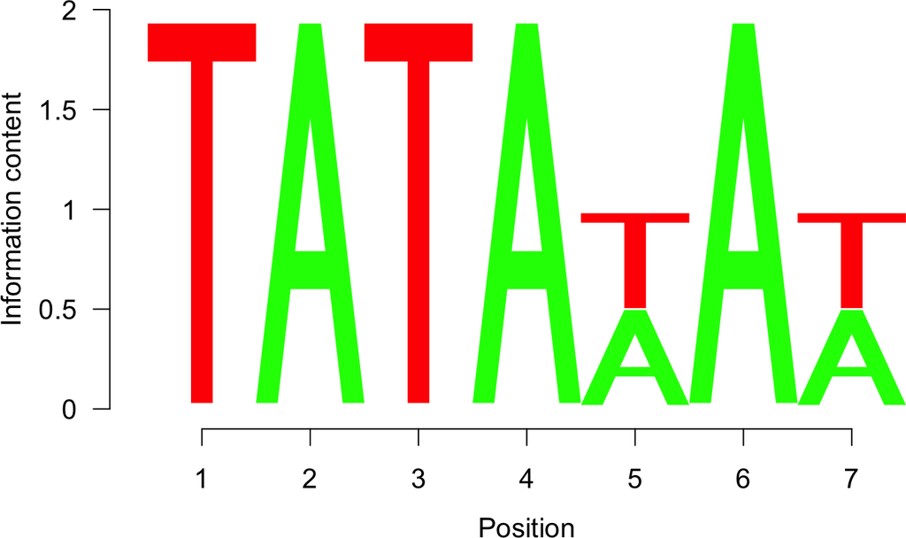

```r
library(universalmotif)
data(examplemotif)

## For all the examples, simply passing the functions a PPM is sufficient
motif <- convert_type(examplemotif, "PPM")
## Only need the matrix itself
motif <- motif["motif"]

## seqLogo:
seqLogo::seqLogo(motif)
```

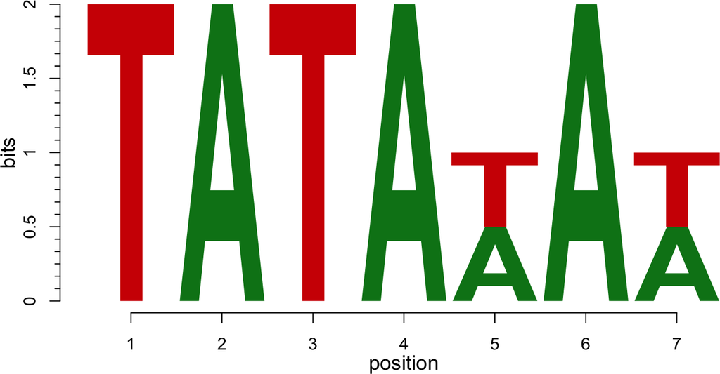

```r
## motifStack:
motifStack::plotMotifLogo(motif)
```

```r
## Logolas:
if (requireNamespace("Logolas", quietly = TRUE)) {
  colnames(motif) <- seq_len(ncol(motif))
  Logolas::logomaker(motif, type = "Logo")
}
```

```
#> color_type not provided, so switching to per_row option for
#>                color_type
#> frame width not provided, taken to be 1
#> using a background with equal probability for all symbols
```

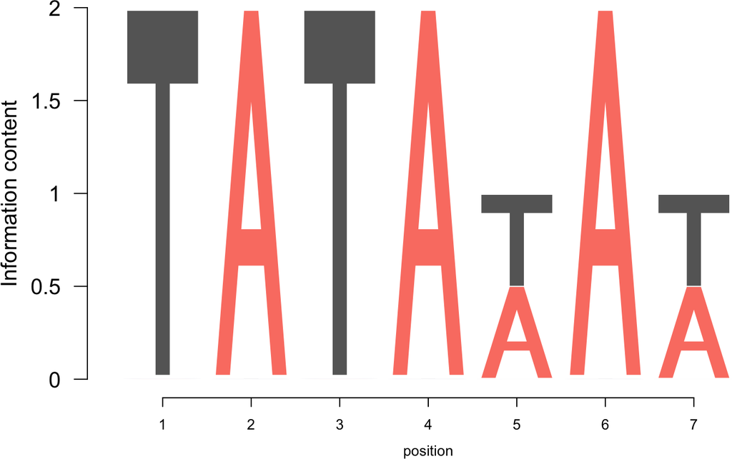

```r
## ggseqlogo:
if (requireNamespace("ggseqlogo", quietly = TRUE)) {
  ggseqlogo::ggseqlogo(motif)
}
```

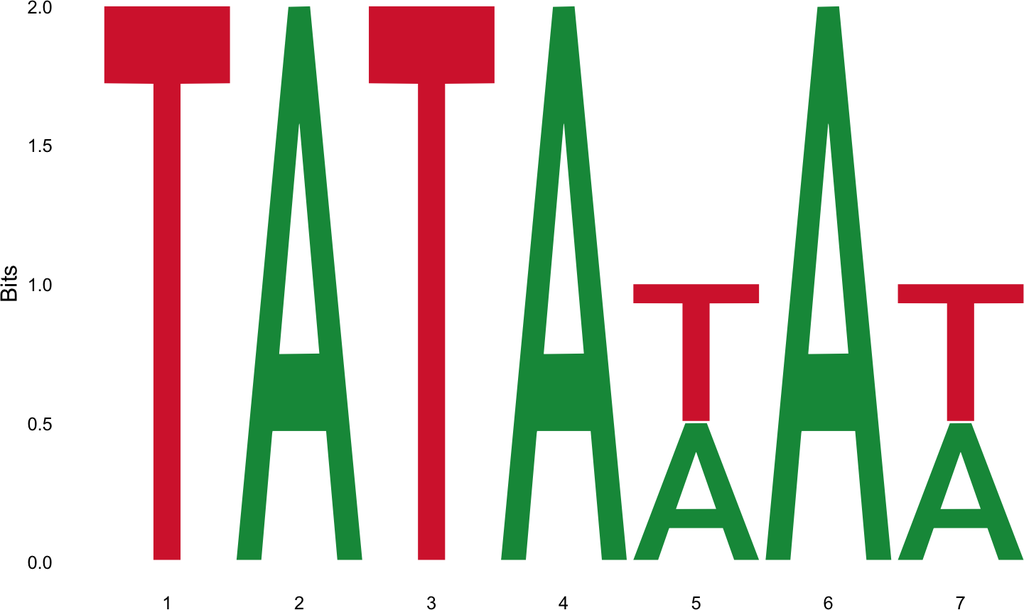

The *Logolas* and *ggseqlogo* offer many additional options for logo customization, including custom alphabets as well as manually determining the heights of each letter, via the *grid* and *ggplot2* packages respectively.

# References

Bailey, T.L., M. Boden, F.A. Buske, M. Frith, C.E. Grant, L. Clementi, J. Ren, W.W. Li, and W.S. Noble. 2009. “MEME Suite: Tools for Motif Discovery and Searching.” *Nucleic Acids Research* 37: W202–W208.

Heinz, S., C. Benner, N. Spann, E. Bertolino, Y.C. Lin, P. Laslo, J.X. Cheng, C. Murre, H. Singh, and C.K. Glass. 2010. “Simple Combinations of Lineage-Determining Transcription Factors Prime Cis-Regulatory Elements Required for Macrophage and B Cell Identities.” *Molecular Cell* 38 (4): 576–89.

Hume, M.A., L.A. Barrera, S.S. Gisselbrecht, and M.L. Bulyk. 2015. “UniPROBE, Update 2015: New Tools and Content for the Online Database of Protein-Binding Microarray Data on Protein-Dna Interactions.” *Nucleic Acids Research* 43: D117–D122.

Khan, A., O. Fornes, A. Stigliani, M. Gheorghe, J.A. Castro-Mondragon, R. van der Lee, A. Bessy, et al. 2018. “JASPAR 2018: Update of the Open-Access Database of Transcription Factor Binding Profiles and Its Web Framework.” *Nucleic Acids Research* 46 (D1): D260–D266.

Weirauch, M.T., A. Yang, M. Albu, A.G. Cote, A. Montenegro-Montero, P. Drewe, H.S. Najafabadi, et al. 2014. “Determination and Inference of Eukaryotic Transcription Factor Sequence Specificity.” *Cell* 158 (6): 1431–43.

Wingender, E., P. Dietze, H. Karas, and R. Knuppel. 1996. “TRANSFAC: A Database on Transcription Factors and Their Dna Binding Sites.” *Nucleic Acids Research* 24 (1): 238–41.